# AID 2025 - Project 3 - Principal Component Analysis

Yair B. Barnatan

2025-07-24

# *Aim*

The aim of this project is to apply Principal Component Analysis (PCA) to linearly reduce the dimensionality of the FIFA 2024 Men dataset, identify patterns in the data, and visualize how players are grouped based on their characteristics.

Data source: provided by course teaching staff.

# *Import libraries*

```r
library(ggplot2)
library(tidyverse)
library(readr)
library(dplyr)
library(tidyr)
library(knitr)
library(kableExtra)
library(ggpubr)
library(purrr)
library(corrplot)
library(viridis)
library(grid)
library(factoextra)
library(ggfortify)
```

# *Data loading*

```r
pathBase = dirname(rstudioapi::getSourceEditorContext()$path)
df = read_csv(paste0(pathBase,"/player_stats.csv"))
```

For this practical assignment, I will work with the FIFA 2024 MEN dataset. I set the random seed for reproducibility to obtain a sample of 2000 individuals.

```r
set.seed(499)
N_IND = 2000
fifa <- df %>% sample_n(N_IND)
attach(fifa)
```

# *Exploratory Data Analysis and Preprocessing*

## 2.1 – Analyze the presence of missing values and duplicate data.

### 2.1.a. Missing values

```r
NA_por_col = data.frame(colSums(is.na(fifa)))
colnames(NA_por_col) <- "NAs"

NA_por_col  %>%
  kable(caption = "Number of NAs", format = "html") %>%
  kable_styling(bootstrap_options = c("striped", "hover", "condensed", "responsive")) %>%
  row_spec(which(NA_por_col$NAs > 0), background = "lightblue")
```

Number of NAs

|  | NAs |
| --- | --- |
| player | 0 |
| country | 0 |
| height | 0 |
| weight | 0 |
| age | 0 |
| club | 0 |
| ball_control | 0 |
| dribbling | 0 |
| marking | 50 |
| slide_tackle | 0 |
| stand_tackle | 0 |
| aggression | 0 |
| reactions | 0 |
| att_position | 0 |
| interceptions | 0 |
| vision | 0 |
| composure | 0 |
| crossing | 0 |
| short_pass | 0 |
| long_pass | 0 |
| acceleration | 0 |
| stamina | 0 |
| strength | 0 |
| balance | 0 |
| sprint_speed | 0 |
| agility | 0 |
| jumping | 0 |
| heading | 0 |
| shot_power | 0 |
| finishing | 0 |
| long_shots | 0 |
| curve | 0 |
| fk_acc | 0 |
| penalties | 0 |
| volleys | 0 |
| gk_positioning | 0 |
| gk_diving | 0 |
| gk_handling | 0 |
| gk_kicking | 0 |
| gk_reflexes | 0 |
| value | 0 |

### 2.1.b. Duplicate values

```r
sum(any(duplicated(fifa)))
```

```
## [1] 0
```

I have 0 duplicate rows.

## 2.2 – Select a relevant subset of variables to perform PCA. Justify the selection.

I must select a subset of attributes to carry out the PCA. To do this, it’s important to choose numerical variables that are not too highly correlated with each other. Additionally, the variables must be scalable (normalized or standardized) so that each one has the same weight in the analysis (I do not assume any variable is more important than the others a priori).

In the case of FIFA players, the following variables may be relevant for PCA:

- *Player characteristics:* age, height, weight.
- *Technical skills:* ball_control, dribbling, aggression, reactions, crossing, short_pass, long_pass, penalties, gk_reflexes, gk_positioning, gk_kicking (I include some variables to represent goalkeeper abilities).
- *Physical skills:* acceleration, stamina, strength, balance, sprint_speed, heading, finishing.

```r
fifa_subset <- fifa[, c('age', 'height', 'weight',
                        'ball_control', 'dribbling', 'aggression', 'reactions', 'crossing',
                        'short_pass', 'long_pass', 'penalties', 'gk_reflexes', 'gk_positioning', 'gk_kicking',
                        'acceleration', 'stamina', 'strength', 'balance', 'sprint_speed', 'heading', 'finishing')]
```

## 3 – Provide a description of the selected numerical variables.

### 3a. Player characteristics

```r
hist_1 <- ggplot(fifa_subset, aes(x = age)) +
  geom_histogram(binwidth = 1, fill = "lightblue", color = "black") +
  labs(title = "a) Age Histogram", x = "Age (years)", y = "Frequency") +
    geom_vline(aes(xintercept = median(age, na.rm = TRUE)),
             linetype = "dashed", color = "black", size = 1) +
  theme_minimal()
min(fifa_subset$age) # youngest
```

```
## [1] 17
```

```r
max(fifa_subset$age) # oldest
```

```
## [1] 41
```

```r
median(fifa_subset$age) # median
```

```
## [1] 26
```

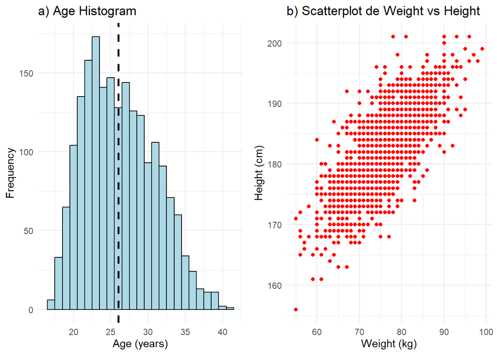

```r
scatter_1 <- ggplot(fifa_subset, aes(x = weight, y = height)) +
  geom_point(color = "red") +
  labs(title = "b) Scatterplot de Weight vs Height", x = "Weight (kg)", y = "Height (cm)") +
  theme_minimal()

ggarrange(hist_1, scatter_1, nrow=1, ncol=2)
```

### 3b. Technical and physical skills

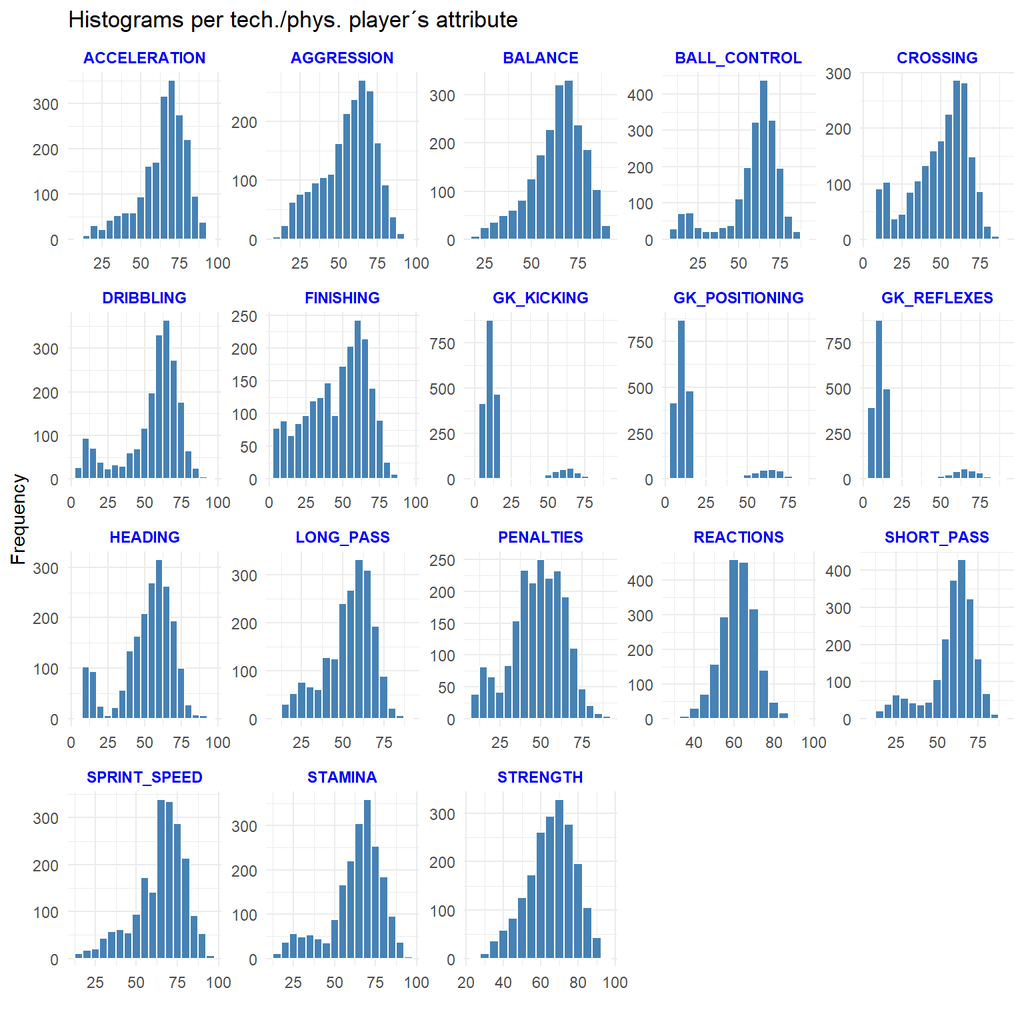

```r
variables <- c('ball_control', 'dribbling', 'aggression', 'reactions', 'crossing',
               'short_pass', 'long_pass', 'penalties', 'gk_reflexes', 'gk_positioning', 'gk_kicking',
               'acceleration', 'stamina', 'strength', 'balance', 'sprint_speed', 'heading', 'finishing')

fifa_subset_hist = fifa_subset
fifa_subset_hist$id <- 1:nrow(fifa_subset)

data_longer <- fifa_subset_hist %>%
  select(id, all_of(variables)) %>%
  pivot_longer(cols = -id, names_to = "variable", values_to = "value")

ggplot(data_longer, aes(x = value)) +
  geom_histogram(binwidth = 5, fill = "steelblue", color = "white") +
   facet_wrap(~ variable, scales = "free",
             labeller = labeller(variable = function(x) toupper(x))) +
  labs(title = "Histograms per tech./phys. player´s attribute",
       x = "", y = "Frequency") +
  theme_minimal() +
  theme(strip.text = element_text(color = "blue", face = "bold"))
```

Analysis of histograms of players’ physical-technical attributes:

- The histograms allow analyzing the distribution of each of the players’ physical and technical variables. For example, some show unimodal trends (acceleration, aggression, balance) and others bimodal (dribbling, heading) with generally asymmetric distributions (except reactions and strength).
- For goalkeeper-related variables, the bars with very low relative frequency observed in the 3 panels clearly represent players who usually play in this position (since they have high attribute values). In comparison, most players are field players (i.e., high relative frequency) and thus have low attribute values.
- Note: this is a univariate analysis and as more and more variables are added, it becomes less interpretable. That is why it is useful to use multivariate and dimensionality reduction methods.

### 3b extra. Technical and physical skills - outliers

```r
data_long <- fifa_subset |>
             select(c('ball_control', 'dribbling', 'aggression', 'reactions', 'crossing',
                        'short_pass', 'long_pass', 'penalties', 'gk_reflexes', 'gk_positioning', 'gk_kicking',
                      'acceleration', 'stamina', 'strength', 'balance', 'sprint_speed', 'heading', 'finishing')) |> reshape2::melt()
```

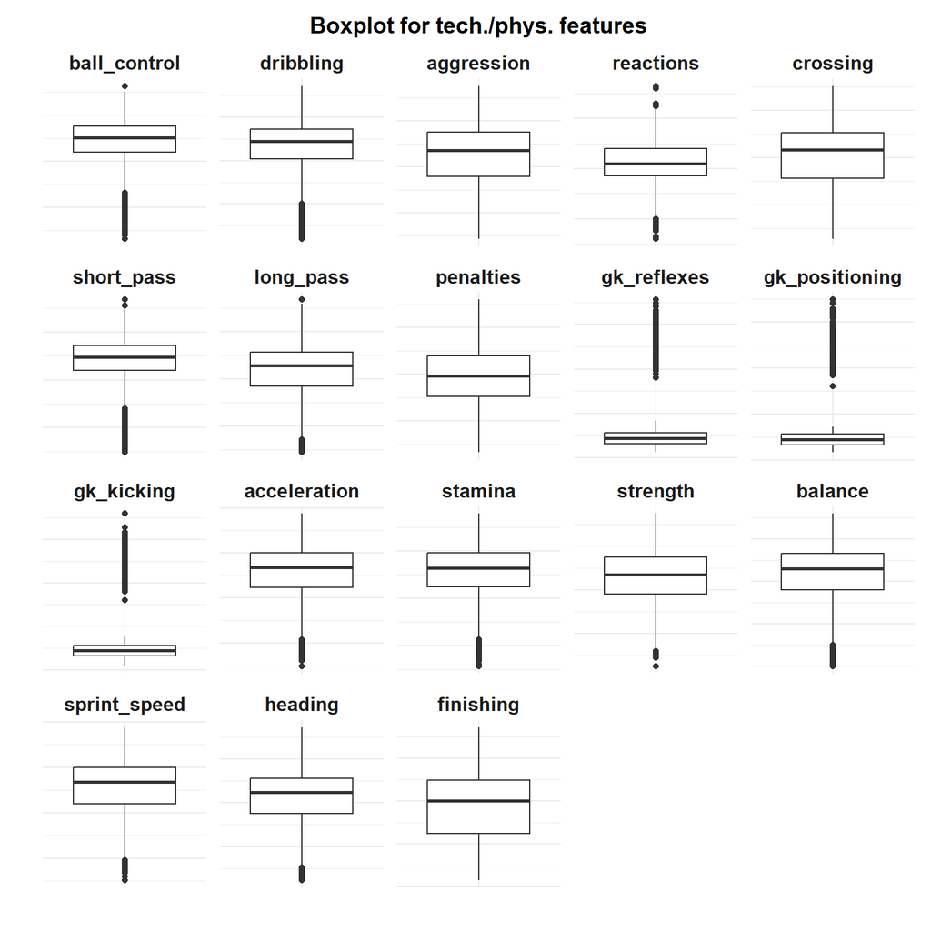

```r
ggplot(data_long, aes(x=variable, y=value)) +
    geom_boxplot() +
    facet_wrap(~variable, scale="free") +
   labs(
    title = "Boxplot for tech./phys. features", x = "",   y = "") +
  theme_minimal() +
  theme(
    plot.title = element_text(size = 14, face = "bold", hjust = 0.5),
    axis.title = element_text(size = 12),
    axis.text = element_blank(),
    strip.text = element_text(size = 12, face = "bold"),
    legend.title = element_text(size = 12),
    legend.text = element_text(size = 10),
    plot.margin = margin(10, 10, 10, 10)
    )
```

```r
# Function to count number of outliers in a column
count_outliers <- function(column) {
  Q1 <- quantile(column, 0.25, na.rm = TRUE)
  Q3 <- quantile(column, 0.75, na.rm = TRUE)
  IQR_value <- IQR(column, na.rm = TRUE)

  lower_bound <- Q1 - 1.5 * IQR_value
  upper_bound <- Q3 + 1.5 * IQR_value

  outliers <- sum(column < lower_bound | column > upper_bound, na.rm = TRUE)
  return(outliers)
}

outliers_count <- sapply(fifa_subset, function(x) if(is.numeric(x)) count_outliers(x) else NA)

data.frame(outliers_count)  %>%
  kable(caption = "Number of outliers per column in fifa_subset", format = "html") %>%
  kable_styling(bootstrap_options = c("striped", "hover", "condensed", "responsive"))
```

Number of outliers per column in fifa_subset

|  | outliers_count |
| --- | --- |
| age | 0 |
| height | 3 |
| weight | 21 |
| ball_control | 232 |
| dribbling | 244 |
| aggression | 0 |
| reactions | 32 |
| crossing | 0 |
| short_pass | 212 |
| long_pass | 40 |
| penalties | 0 |
| gk_reflexes | 234 |
| gk_positioning | 234 |
| gk_kicking | 234 |
| acceleration | 60 |
| stamina | 118 |
| strength | 12 |
| balance | 46 |
| sprint_speed | 33 |
| heading | 145 |
| finishing | 0 |

Analisis:

- The set of boxplots for players’ technical skills shows the presence of outliers for most of the selected variables.
- Decision: do not remove them for now, since as shown, they represent a large portion of the dataset. (The presence of outliers will be important in section 8 where robust PCA methodologies [i.e., robust against outliers] are applied)

### 3c. Correlation matrix

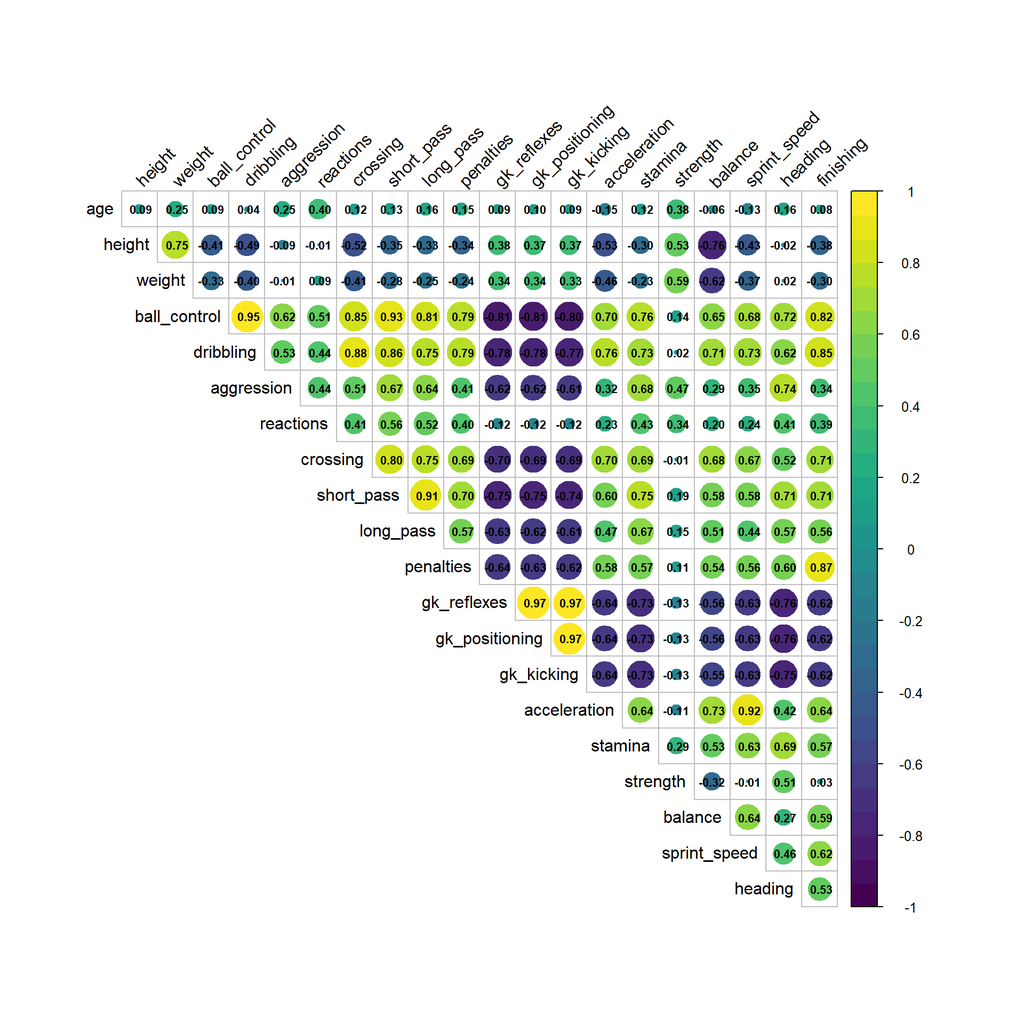

```r
m_cor <- cor(fifa_subset)

corrplot(m_cor, method="circle", type = "upper", diag= FALSE,
          addCoef.col = "black", tl.col = "black", tl.srt = 45, number.cex = 0.7,  col = viridis(30))
```

Analysis:

From the correlation matrix I can study:

- Highly correlated variables (both positively and negatively): values close to 1 or -1 with colors close to yellow or blue, the extremes of the scale.
- Uncorrelated or moderately correlated variables: values close to 0, with green or bluish-green colors on the scale.

## 4- Were the variables standardized? Justify.

Analysis:

- The correlation plot per se shows exactly that: the linear correlation between variables.
- To standardize, the scale() command must be run beforehand.
- For this practical work, in the next step (PCA and interpretation), I must standardize the variables since they are in different units and I also want to avoid giving greater weight to one variable over another.

# *PCA and interpretation.*

## 5- Perform PCA on the selected variables. How many components do you decide to keep after dimensionality reduction?

To run a PCA I must:

- Standardize the data
- Calculate the correlation or covariance matrix [in this case I use correlation since the variables have different units and I don’t want to give preferential weight to one over the others]
- Obtain eigenvalues and eigenvectors
- Select number of principal components (PCs)
- Project the original data onto the new set of synthetic PCs
- Interpret the results

Note: it is advisable that the variables introduced in the PCA are correlated; if not, running PCA will not add any value to the analysis.

```r
# Standardize the data
fifa_subset_scaled = data.frame(scale(fifa_subset))
M_corr = cor(fifa_subset_scaled)
traza = sum(diag(M_corr))
traza
```

```
## [1] 21
```

```r
pca <- prcomp((fifa_subset), scale = TRUE)
round(pca$rotation,2) |> knitr::kable(format = "html") |>  kable_styling()
```

|  | PC1 | PC2 | PC3 | PC4 | PC5 | PC6 | PC7 | PC8 | PC9 | PC10 | PC11 | PC12 | PC13 | PC14 | PC15 | PC16 | PC17 | PC18 | PC19 | PC20 | PC21 |
| --- | --- | --- | --- | --- | --- | --- | --- | --- | --- | --- | --- | --- | --- | --- | --- | --- | --- | --- | --- | --- | --- |
| age | -0.02 | -0.29 | -0.44 | -0.20 | 0.13 | -0.70 | -0.21 | 0.26 | -0.14 | 0.09 | 0.03 | 0.17 | 0.00 | 0.09 | -0.01 | -0.02 | 0.00 | 0.00 | -0.01 | 0.01 | 0.01 |
| height | 0.15 | -0.38 | 0.18 | 0.28 | 0.02 | 0.23 | -0.14 | 0.32 | -0.01 | 0.08 | -0.24 | 0.40 | -0.56 | -0.03 | -0.12 | 0.01 | -0.04 | 0.00 | -0.01 | 0.01 | -0.01 |
| weight | 0.12 | -0.41 | 0.06 | 0.30 | 0.00 | 0.02 | -0.41 | -0.54 | -0.24 | 0.31 | -0.10 | -0.11 | 0.27 | -0.02 | 0.09 | -0.02 | 0.01 | 0.01 | 0.00 | 0.00 | 0.00 |
| ball_control | -0.28 | -0.04 | -0.07 | 0.03 | 0.09 | 0.14 | -0.04 | 0.03 | -0.06 | 0.00 | 0.07 | -0.04 | -0.09 | 0.20 | 0.14 | -0.44 | 0.15 | 0.08 | 0.35 | -0.67 | 0.11 |
| dribbling | -0.28 | 0.04 | -0.09 | 0.11 | 0.09 | 0.09 | -0.10 | 0.02 | -0.01 | -0.02 | -0.07 | -0.16 | -0.14 | 0.28 | 0.13 | -0.46 | 0.11 | -0.50 | -0.20 | 0.45 | -0.07 |
| aggression | -0.19 | -0.27 | 0.09 | -0.36 | -0.22 | -0.04 | 0.20 | -0.26 | -0.13 | -0.40 | -0.59 | 0.10 | 0.03 | 0.21 | -0.07 | 0.01 | -0.03 | 0.03 | 0.01 | -0.01 | 0.00 |
| reactions | -0.13 | -0.25 | -0.48 | 0.06 | -0.25 | 0.31 | 0.41 | 0.12 | -0.25 | 0.32 | 0.06 | -0.24 | 0.01 | 0.04 | -0.29 | 0.16 | 0.01 | -0.05 | -0.03 | -0.01 | -0.01 |
| crossing | -0.26 | 0.05 | -0.15 | -0.04 | -0.01 | 0.02 | -0.39 | 0.13 | 0.09 | -0.10 | -0.32 | -0.58 | -0.27 | -0.36 | 0.08 | 0.20 | -0.08 | 0.14 | 0.01 | -0.03 | 0.00 |
| short_pass | -0.27 | -0.10 | -0.10 | -0.13 | 0.04 | 0.28 | -0.14 | 0.03 | -0.04 | -0.06 | 0.21 | 0.18 | 0.09 | 0.02 | 0.08 | -0.21 | 0.01 | 0.71 | -0.19 | 0.33 | -0.06 |
| long_pass | -0.23 | -0.10 | -0.16 | -0.29 | 0.00 | 0.37 | -0.39 | -0.02 | 0.09 | -0.16 | 0.23 | 0.33 | 0.18 | -0.13 | -0.05 | 0.29 | -0.06 | -0.43 | 0.08 | -0.08 | 0.03 |
| penalties | -0.23 | -0.03 | -0.13 | 0.30 | 0.44 | -0.08 | 0.21 | -0.13 | 0.12 | -0.16 | -0.16 | 0.15 | 0.19 | -0.50 | -0.39 | -0.20 | 0.04 | -0.02 | 0.04 | 0.02 | 0.01 |
| gk_reflexes | 0.26 | 0.00 | -0.32 | 0.10 | -0.13 | 0.08 | 0.04 | -0.05 | 0.11 | -0.16 | -0.08 | 0.06 | 0.00 | -0.05 | 0.23 | -0.07 | -0.01 | 0.03 | 0.30 | 0.26 | 0.73 |
| gk_positioning | 0.26 | 0.00 | -0.33 | 0.10 | -0.13 | 0.07 | 0.03 | -0.06 | 0.12 | -0.17 | -0.06 | 0.06 | -0.01 | -0.07 | 0.21 | -0.09 | -0.02 | 0.02 | 0.47 | 0.13 | -0.67 |
| gk_kicking | 0.26 | 0.00 | -0.33 | 0.09 | -0.12 | 0.08 | 0.04 | -0.07 | 0.13 | -0.19 | -0.08 | 0.10 | 0.01 | -0.13 | 0.25 | -0.13 | -0.01 | -0.04 | -0.69 | -0.38 | -0.05 |
| acceleration | -0.23 | 0.18 | 0.02 | 0.33 | -0.39 | -0.14 | -0.09 | 0.07 | -0.13 | -0.07 | 0.04 | 0.11 | 0.10 | 0.03 | -0.09 | -0.14 | -0.74 | -0.01 | 0.02 | -0.05 | 0.02 |
| stamina | -0.24 | -0.11 | 0.06 | -0.07 | -0.30 | -0.09 | 0.06 | 0.04 | 0.68 | 0.50 | -0.19 | 0.12 | 0.16 | -0.06 | 0.11 | -0.08 | 0.05 | 0.01 | 0.01 | 0.00 | 0.00 |
| strength | -0.03 | -0.49 | 0.11 | 0.11 | -0.15 | -0.17 | 0.07 | -0.15 | 0.37 | -0.38 | 0.49 | -0.27 | -0.20 | 0.05 | -0.14 | 0.00 | -0.01 | -0.01 | -0.01 | 0.01 | 0.01 |
| balance | -0.21 | 0.27 | -0.15 | -0.06 | -0.12 | -0.15 | 0.06 | -0.57 | -0.08 | 0.18 | 0.15 | 0.24 | -0.58 | -0.14 | 0.00 | 0.07 | 0.07 | 0.02 | -0.01 | 0.02 | 0.00 |
| sprint_speed | -0.22 | 0.12 | 0.06 | 0.39 | -0.43 | -0.15 | -0.11 | 0.17 | -0.17 | -0.22 | 0.00 | 0.13 | 0.15 | -0.05 | 0.02 | 0.19 | 0.61 | 0.02 | -0.01 | 0.01 | -0.01 |
| heading | -0.22 | -0.27 | 0.21 | -0.02 | 0.07 | -0.05 | 0.35 | 0.11 | -0.27 | 0.02 | 0.12 | 0.03 | 0.00 | -0.40 | 0.64 | 0.06 | -0.11 | -0.13 | 0.02 | 0.05 | -0.01 |
| finishing | -0.24 | 0.03 | -0.16 | 0.37 | 0.38 | 0.00 | 0.12 | -0.08 | 0.20 | -0.05 | -0.09 | 0.07 | 0.01 | 0.47 | 0.25 | 0.51 | -0.11 | 0.09 | -0.03 | -0.03 | -0.01 |

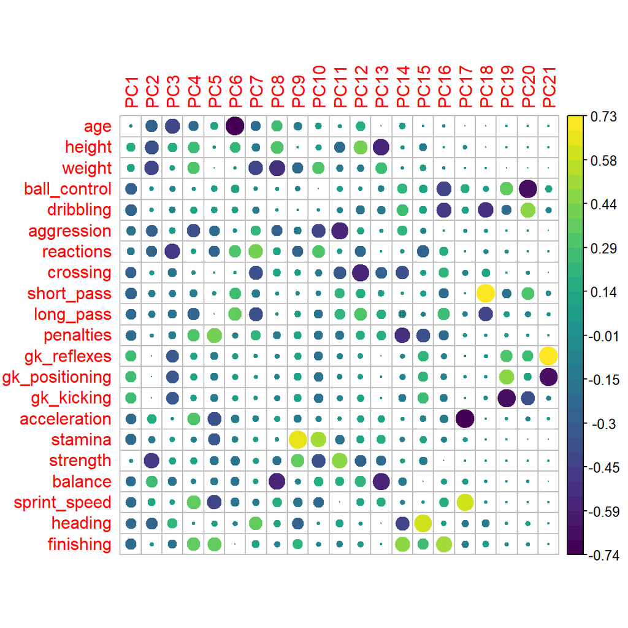

```r
contrib <- as.matrix(round(pca$rotation,2))
corrplot(contrib,is.corr=FALSE,  col = viridis(30))
```

### 5a. Loading analysis: indicates the importance or weight of each original variable on each of the new PCs.

The loading can also be viewed by component, which allows better discerning which variables weigh more on each component. For illustrative purposes, the first 3 PCs are shown.

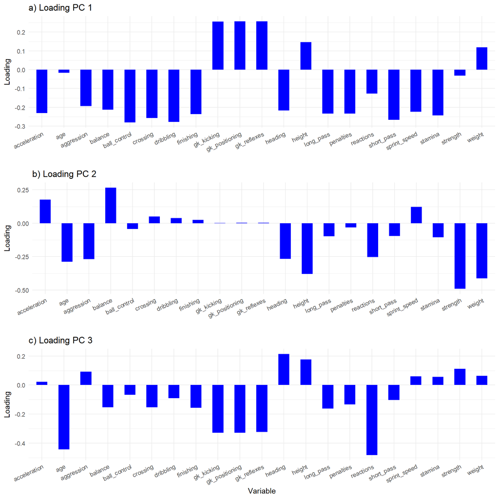

```r
carga1 = data.frame(cbind(X=1:length(fifa_subset), primeracarga=data.frame(pca$rotation)[,1]))
carga2 = data.frame(cbind(X=1:length(fifa_subset), segundacarga=data.frame(pca$rotation)[,2]))
carga3 = data.frame(cbind(X=1:length(fifa_subset), terceracarga=data.frame(pca$rotation)[,3]))

barplot_1 = ggplot(carga1, aes(colnames(fifa_subset), primeracarga)) +
       geom_bar (stat="identity" , position="dodge" , fill ="blue" , width =0.5) +
        xlab( '') + ylab('Loading') + ggtitle("a) Loading PC 1") +
  theme_minimal() +
  theme(axis.text.x = element_text(angle = 25, hjust = 1))

barplot_2 = ggplot(carga2, aes(colnames(fifa_subset), segundacarga)) +
       geom_bar (stat="identity" , position="dodge" , fill ="blue" , width =0.5) +
        xlab( '') + ylab('Loading') + ggtitle("b) Loading PC 2") +
  theme_minimal() +
  theme(axis.text.x = element_text(angle = 25, hjust = 1))

barplot_3 = ggplot(carga3, aes(colnames(fifa_subset), terceracarga)) +
       geom_bar (stat="identity" , position="dodge" , fill ="blue" , width =0.5) +
        xlab( 'Variable') + ylab('Loading') + ggtitle("c) Loading PC 3") +
  theme_minimal() +
  theme(axis.text.x = element_text(angle = 25, hjust = 1))

ggarrange(barplot_1, barplot_2, barplot_3, ncol = 1, nrow=3)
```

### 5b. Eigenvalue analysis - selection of the number of components

There is no single criterion, and in some cases the determination of the cutoff point is arbitrary and set by the researcher (as in criterion 1). Therefore, the strategy is to perform more than one method of analysis to determine the number of PCs to select for analysis and interpretation in terms of the problem being studied.

#### Criterion 1: % of explained variance

The researcher selects a priori how many PCs to retain.

```r
pca$sdev^2
```

```
##  [1] 11.67309714  3.20534288  1.55414640  0.94291680  0.73263073  0.67181275
##  [7]  0.37205272  0.27604664  0.25071730  0.22705948  0.20788575  0.18573323
## [13]  0.16618202  0.13727035  0.11917554  0.07166129  0.06794092  0.04849434
## [19]  0.03314135  0.03133809  0.02535429
```

```r
prop_varianza <- pca$sdev^2 / sum(pca$sdev^2)
prop_varianza
```

```
##  [1] 0.555861769 0.152635375 0.074006971 0.044900800 0.034887177 0.031991083
##  [7] 0.017716796 0.013145078 0.011938919 0.010812356 0.009899322 0.008844439
## [13] 0.007913430 0.006536683 0.005675026 0.003412442 0.003235282 0.002309254
## [19] 0.001578159 0.001492290 0.001207347
```

```r
p_var = data.frame(prop_varianza = prop_varianza,
                   PC = 1:length(prop_varianza))

porc_var = ggplot(data = p_var, aes(x = PC, y = prop_varianza)) +
  geom_col(width = 0.8, fill='gold') +
  theme_bw() +
  labs(x = "PC", y = "Proportion of \nthe explained variance")


prop_varianza <- pca$sdev^2 / sum(pca$sdev^2)
prop_varianza_acum <- cumsum(prop_varianza)

porc_var_acum = ggplot(data = p_var,
       aes(x = PC, y = prop_varianza_acum, group = 1)) +
  geom_point( color='gold', size=2, alpha=0.8) +
  geom_line(color='black', size=0.5) +
  theme_bw() +
  labs(x = "PC", y = "Cummulative proportion of \nthe explained variance")+
  ggtitle("a) Cumulative explained variance proportion by PC\nInset: Explained variance proportion")

# Combinar ambos gráficos
inset_grob <- ggplotGrob(porc_var)
prop_var_c_inset = porc_var_acum + annotation_custom(grob = inset_grob, xmin = 7, xmax = 20, ymin = 0.55, ymax = 0.85)
```

#### Criterion 2: Kaiser Criterion

This consists of selecting PCs whose eigenvalues are >= 1.

```r
AV = data.frame(autoval = pca$sdev^2, PC = 1:length(pca$sdev^2))

kaiser = ggplot(data = AV , aes(x = PC, y = autoval)) +
  geom_col(width = 0.8, fill='orange') +
  theme_bw() +
  labs(x = "PC", y = "Autovalue")+
  ggtitle("b) Kaiser's criterion") +
  geom_hline(yintercept = 1, linetype = "dashed", color = "black", size = 1)
```

#### Criterion 3: Broken Stick Criterion or Scree Plot

This consists of keeping all the PCs that consistently produce a decrease in the % of unexplained variability. If adding more PCs does not reduce the % of variability left to explain, it makes no sense to keep adding PCs, as it only complicates the analysis.

```r
baston = fviz_eig(pca, ncp = traza, addlabels = TRUE, main="c) Broken stick criterion", barfill = "red") +
  xlab("PC") +
  ylab("PExplained variance percentage (%)")  +
  ylim(0,60)
```

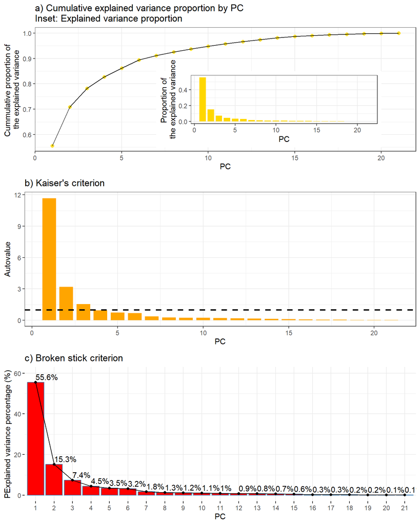

```r
ggarrange(prop_var_c_inset, kaiser, baston, ncol=1, nrow=3)
```

## 6- Interpret the factor loadings of the first two principal components. Which player attributes are most represented in each component? Show the PCA biplot.

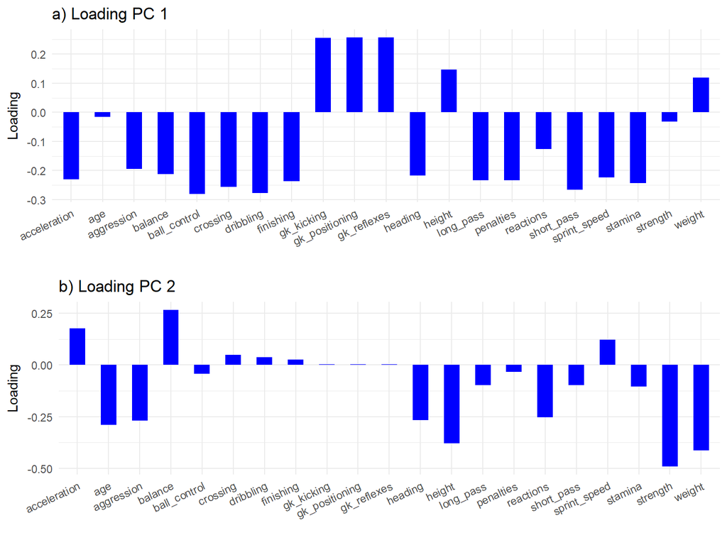

```r
#Loading of variables on PC1 y PC2
ggarrange(barplot_1, barplot_2,  ncol = 1, nrow=2)
```

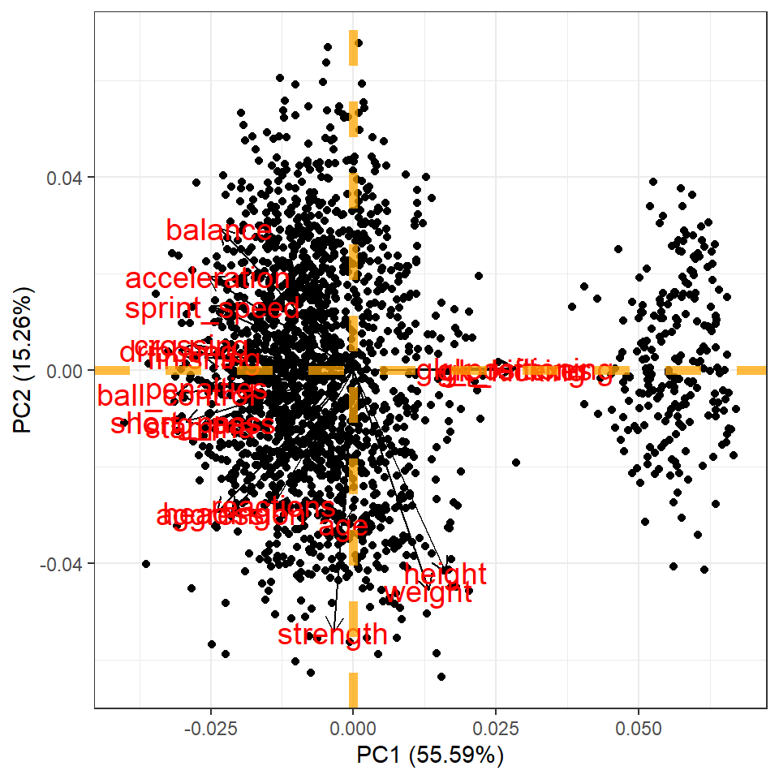

```r
# Biplot PC1 and PC2
autoplot(pca,
         data = fifa_subset,
         loadings = TRUE,
         loadings.colour = 'black',
         loadings.label = TRUE,
         loadings.label.size = 5) +
  geom_vline(xintercept = 0, linetype = "dashed", color = "orange", size=2, alpha=0.75) +
  geom_hline(yintercept = 0, linetype = "dashed", color = "orange", size=2, alpha=0.75)+
    theme_bw()
```

Analysis:

- The factor loadings of the variables on the first two PCs involve analyzing the weight or influence of these variables on each of the synthetic components generated by PCA.
- *PC1:* This component shows that almost all variables either correlate positively or negatively; there are a few with little or no weight (age, strength). Those that correlate positively refer to attributes of players who play as goalkeepers (gk_kicking, gk_positioning, gk_reflexes). Those that correlate negatively are all important for field players. It was expected that since the distinction between field player vs. goalkeeper is very noticeable in the development of the game and player movements, these variables are key when grouping players. The interpretability given to PC1 is to suggest a grouping of players based on their position on the field (goalkeeper vs. field player).
- *PC2:* The second component allows analyzing what happens once I distinguish according to PC1 (i.e., field player or goalkeeper) and mostly has variables that correlate negatively or have no correlation. Analyzing those that correlate most negatively, what adds to the grouping of players are: age, aggression, heading, weight, strength, and height. That is, players seem to group according to their age, physical characteristics of height and weight (player-specific traits), and based on their aggressiveness in play, heading ability, and strength applied during play (technical characteristics).
- A similar analysis can be done by observing the *biplot*, which shows the data in the reference frame of the first two PCs (each showing the % of total variability explained by the data). Horizontal and vertical lines crossing at (0,0) were added to facilitate interpretation of what correlates positively and negatively with respect to each PC. As mentioned earlier, there is a clear separation in the data that probably corresponds to the differentiation between field player vs. goalkeeper (horizontal separation, related to PC1). The weight of each variable can be seen as the vector it forms with respect to (0,0) and its loading as the orthogonal projection onto each of the PCs.

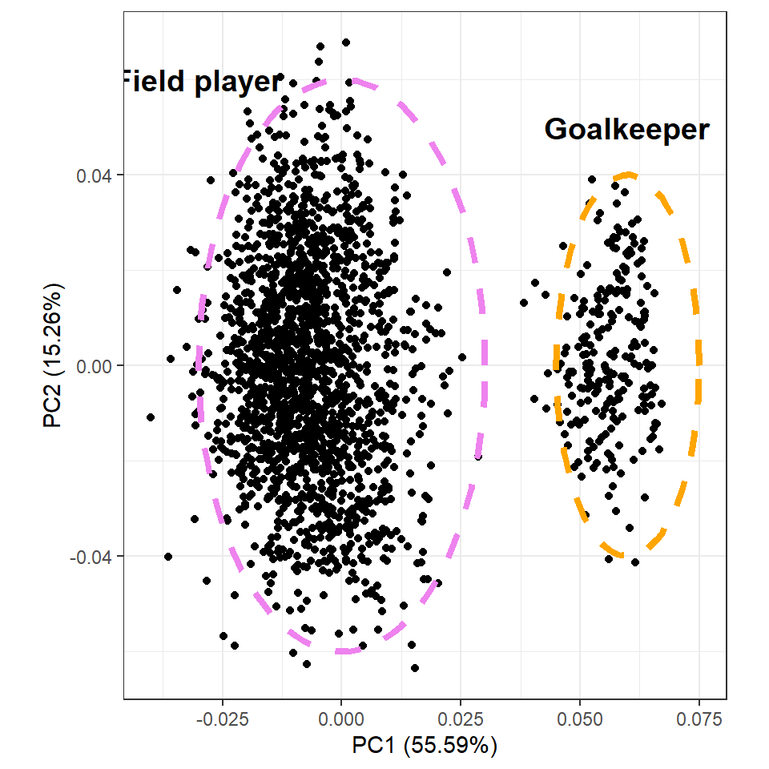

```r
#Same biplot but specifying cloud of datapoints pertaining to field players vs goalkeepers
generar_elipse <- function(cx, cy, rx, ry, n = 100) {
  t <- seq(0, 2 * pi, length.out = n)
  data.frame(
    x = cx + rx * cos(t),
    y = cy + ry * sin(t)
  )
}

elipse_campo =  generar_elipse(cx = 0, cy = 0, rx = 0.03, ry = 0.06)
elipse_arquero = generar_elipse(cx = 0.06, cy = 0, rx = 0.015, ry = 0.04)

autoplot(pca, data = fifa_subset) +
  geom_path(data = elipse_campo, aes(x = x, y = y), color = "violet", linetype = "dashed", size=1.5) +
  annotate("text", x = -0.03 , y = 0.06, label = "Field player", size = 5, fontface = "bold") +
  geom_path(data = elipse_arquero, aes(x = x, y = y), color = "orange", linetype = "dashed", size=1.5) +
  annotate("text", x = 0.06 , y = 0.05, label = "Goalkeeper", size = 5, fontface = "bold") +
  coord_equal() +
    theme_bw()
```

- Note: To simplify the problem, in this item only PC1 and PC2 are requested to be analyzed, and that is what is done (in light of the analysis in item 5).

## 7- Identify if there are natural groupings of players based on the selected characteristics. Interpret and conclude.

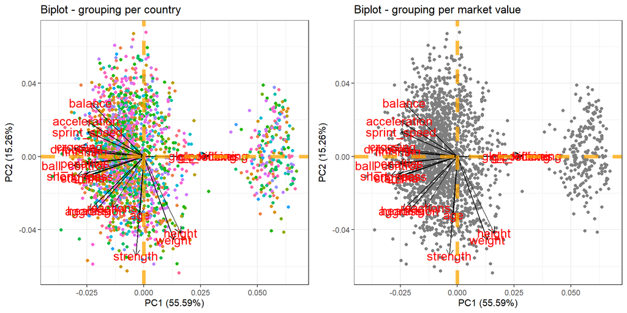

```r
fifa_subset_y_paises = fifa[, c('country', 'age', 'height', 'weight',
                        'ball_control', 'dribbling', 'aggression', 'reactions', 'crossing',
                        'short_pass', 'long_pass', 'penalties', 'gk_reflexes', 'gk_positioning', 'gk_kicking',
                        'acceleration', 'stamina', 'strength', 'balance', 'sprint_speed', 'heading', 'finishing')]

# Biplot PC1 and PC2 - colour by country
biplot_x_pais = autoplot(pca,
         data = fifa_subset_y_paises ,
         colour='country',
         loadings = TRUE,
         loadings.colour = 'black',
         loadings.label = TRUE,
         loadings.label.size = 5) +
  geom_vline(xintercept = 0, linetype = "dashed", color = "orange", size=2, alpha=0.75) +
  geom_hline(yintercept = 0, linetype = "dashed", color = "orange", size=2, alpha=0.75)+
  ggtitle("Biplot - grouping per country")+
  theme_bw()  +   theme(legend.position = "none")

# Biplot PC1 and PC2 - colour by player's price

fifa_subset_y_valor = fifa[, c('value', 'age', 'height', 'weight',
                        'ball_control', 'dribbling', 'aggression', 'reactions', 'crossing',
                        'short_pass', 'long_pass', 'penalties', 'gk_reflexes', 'gk_positioning', 'gk_kicking',
                        'acceleration', 'stamina', 'strength', 'balance', 'sprint_speed', 'heading', 'finishing')]


fifa_subset_y_valor$value =  as.numeric(gsub("\\.", "", gsub("\\$", "", fifa_subset_y_valor$value )))

fifa_subset_y_valor$value <- cut(fifa_subset_y_valor$value,
                            breaks = quantile(fifa_subset_y_valor$value, probs = 0:3 / 3),
                            labels = c("Low market value", "Medium market value", "High market value"),
                            include.lowest = TRUE, right = FALSE)


biplot_x_valor = autoplot(pca,
         data = fifa_subset_y_valor ,
         colour='value',
         loadings = TRUE,
         loadings.colour = 'black',
         loadings.label = TRUE,
         loadings.label.size = 5) +
  geom_vline(xintercept = 0, linetype = "dashed", color = "orange", size=2, alpha=0.75) +
  geom_hline(yintercept = 0, linetype = "dashed", color = "orange", size=2, alpha=0.75)+
  ggtitle("Biplot - grouping per market value") +
   scale_colour_manual(values = c("Barato" = "gold", "Medio" = "brown", "Caro" = "steelblue")) +
  theme_bw()

ggarrange(biplot_x_pais, biplot_x_valor, nrow = 1, ncol = 2)
```

## 8- Choose a robust PCA technique and apply it to the database. Compare the results with those obtained previously. Conclude.

In item 3b, the presence of outliers was mentioned, and that could affect the PCA results and the conclusions drawn. Therefore, a robust PCA method, which is resilient to outliers, is also applied.

### Chosen method: MCD (Minimum Covariance Determinant)

```r
pca_mcd <-princomp(fifa_subset, cor=TRUE, scores=TRUE, covmat=MASS::cov.mcd(fifa_subset))#
summary(pca_mcd)
```

```
## Importance of components:
##                           Comp.1    Comp.2     Comp.3     Comp.4     Comp.5
## Standard deviation     2.5074242 2.1264359 1.26859919 1.15159872 1.07650858
## Proportion of Variance 0.2993894 0.2153205 0.07663542 0.06315141 0.05518432
## Cumulative Proportion  0.2993894 0.5147098 0.59134524 0.65449665 0.70968097
##                            Comp.6     Comp.7     Comp.8     Comp.9   Comp.10
## Standard deviation     0.99292568 0.96060720 0.89471831 0.76201161 0.7216662
## Proportion of Variance 0.04694769 0.04394125 0.03812004 0.02765056 0.0248001
## Cumulative Proportion  0.75662866 0.80056991 0.83868995 0.86634050 0.8911406
##                           Comp.11   Comp.12    Comp.13    Comp.14    Comp.15
## Standard deviation     0.62115051 0.5842487 0.53607296 0.52096702 0.47175096
## Proportion of Variance 0.01837276 0.0162546 0.01368449 0.01292413 0.01059757
## Cumulative Proportion  0.90951336 0.9257680 0.93945245 0.95237657 0.96297414
##                            Comp.16     Comp.17     Comp.18     Comp.19
## Standard deviation     0.448993451 0.446351702 0.375461455 0.326058473
## Proportion of Variance 0.009599768 0.009487135 0.006712919 0.005062578
## Cumulative Proportion  0.972573911 0.982061047 0.988773966 0.993836544
##                            Comp.20     Comp.21
## Standard deviation     0.274076929 0.233054550
## Proportion of Variance 0.003577055 0.002586401
## Cumulative Proportion  0.997413599 1.000000000
```

[figure not shown]

```r
# Grafico loadings de cada variable sobre cada PC segun metodo PCA - MCD

cargas_mcd = data.frame(cbind(X=1:length(fifa_subset), primeracarga=data.frame(pca_mcd$loadings)[,1]))

barplot_1_mcd = ggplot(cargas_mcd, aes(colnames(fifa_subset), Comp.1)) +
       geom_bar (stat="identity" , position="dodge" , fill ="pink" , width =0.5) +
        xlab( '') + ylab('Loading') + ggtitle("a) Loading PC 1 [MCD]") +
  theme_minimal() +
  theme(axis.text.x = element_text(angle = 25, hjust = 1))

barplot_2_mcd = ggplot(cargas_mcd, aes(colnames(fifa_subset), Comp.2)) +
       geom_bar (stat="identity" , position="dodge" , fill ="pink" , width =0.5) +
        xlab( '') + ylab('Loading') + ggtitle("b) Loading PC 2 [MCD]") +
  theme_minimal() +
  theme(axis.text.x = element_text(angle = 25, hjust = 1))

barplot_3_mcd = ggplot(cargas_mcd, aes(colnames(fifa_subset), Comp.3)) +
       geom_bar (stat="identity" , position="dodge" , fill ="pink" , width =0.5) +
        xlab( 'Variable') + ylab('Loading') + ggtitle("c) Loading PC 3 [MCD]") +
  theme_minimal() +
  theme(axis.text.x = element_text(angle = 25, hjust = 1))

ggarrange(barplot_1_mcd, barplot_2_mcd, barplot_3_mcd, ncol = 1, nrow=3)
```

Analysis: when applying a robust method to outliers, the analysis changes significantly; for example, for PC1, the variables that correlate most with it are not the goalkeeper attributes but a large number of other physical and technical variables of the players. There is no single variable that correlates extremely more than the others with PC1, so I do not expect players to be separated based on one variable but rather on a combination of them.

```r
pca_mcd$sdev^2
```

```
##     Comp.1     Comp.2     Comp.3     Comp.4     Comp.5     Comp.6     Comp.7
## 6.28717636 4.52172980 1.60934391 1.32617962 1.15887073 0.98590140 0.92276620
##     Comp.8     Comp.9    Comp.10    Comp.11    Comp.12    Comp.13    Comp.14
## 0.80052086 0.58066169 0.52080208 0.38582795 0.34134660 0.28737422 0.27140663
##    Comp.15    Comp.16    Comp.17    Comp.18    Comp.19    Comp.20    Comp.21
## 0.22254897 0.20159512 0.19922984 0.14097130 0.10631413 0.07511816 0.05431442
```

```r
prop_varianza_mcd <- pca_mcd$sdev^2 / sum(pca_mcd$sdev^2)
prop_varianza_mcd
```

```
##      Comp.1      Comp.2      Comp.3      Comp.4      Comp.5      Comp.6
## 0.299389350 0.215320467 0.076635424 0.063151410 0.055184321 0.046947686
##      Comp.7      Comp.8      Comp.9     Comp.10     Comp.11     Comp.12
## 0.043941248 0.038120041 0.027650557 0.024800099 0.018372760 0.016254600
##     Comp.13     Comp.14     Comp.15     Comp.16     Comp.17     Comp.18
## 0.013684487 0.012924125 0.010597570 0.009599768 0.009487135 0.006712919
##     Comp.19     Comp.20     Comp.21
## 0.005062578 0.003577055 0.002586401
```

```r
p_var_mcd = data.frame(prop_varianza = prop_varianza_mcd,
                   PC = 1:length(prop_varianza_mcd))

porc_var_mcd = ggplot(data = p_var_mcd, aes(x = PC, y = prop_varianza_mcd)) +
  geom_col(width = 0.8, fill='gold') +
  theme_bw() +
  labs(x = "PC", y = "Variance explained proportion")


prop_varianza_mcd <- pca_mcd$sdev^2 / sum(pca_mcd$sdev^2)
prop_varianza_acum_mcd <- cumsum(prop_varianza_mcd)

porc_var_acum_mcd = ggplot(data = p_var_mcd,
       aes(x = PC, y = prop_varianza_acum_mcd, group = 1)) +
  geom_point( color='gold', size=2, alpha=0.8) +
  geom_line(color='black', size=0.5) +
  theme_bw() +
  labs(x = "PC", y = "Cummulative variance explained proportion [MCD]")+
  ggtitle("a) Cumulative explained variance proportion by PC [MCD]\nInset: Explained variance proportion")

inset_grob_mcd <- ggplotGrob(porc_var_mcd)
prop_var_c_inset_mcd = porc_var_acum_mcd + annotation_custom(grob = inset_grob_mcd, xmin = 7, xmax = 20, ymin = 0.25, ymax = 0.55)

AV_mcd = data.frame(autoval = pca_mcd$sdev^2, PC = 1:length(pca_mcd$sdev^2))

kaiser_mcd = ggplot(data = AV_mcd , aes(x = PC, y = autoval)) +
  geom_col(width = 0.8, fill='orange') +
  theme_bw() +
  labs(x = "PC", y = "Autovalue")+
  ggtitle("b) Kaiser's criterion [MCD]") +
  geom_hline(yintercept = 1, linetype = "dashed", color = "black", size = 1)


baston_mcd = fviz_eig(pca_mcd, ncp = traza, addlabels = TRUE, main="c) Broken stick criterion [MCD]", barfill = "red") +
  xlab("PC") +
  ylab("Variance explained percentage (%)")  +
  ylim(0,35)
```

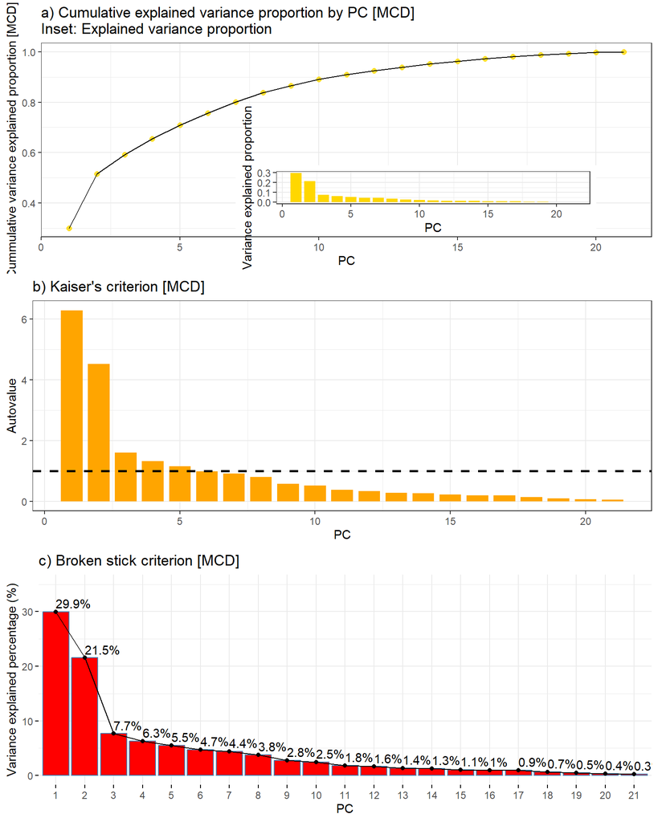

```r
ggarrange(prop_var_c_inset_mcd, kaiser_mcd, baston_mcd, ncol=1, nrow=3)
```

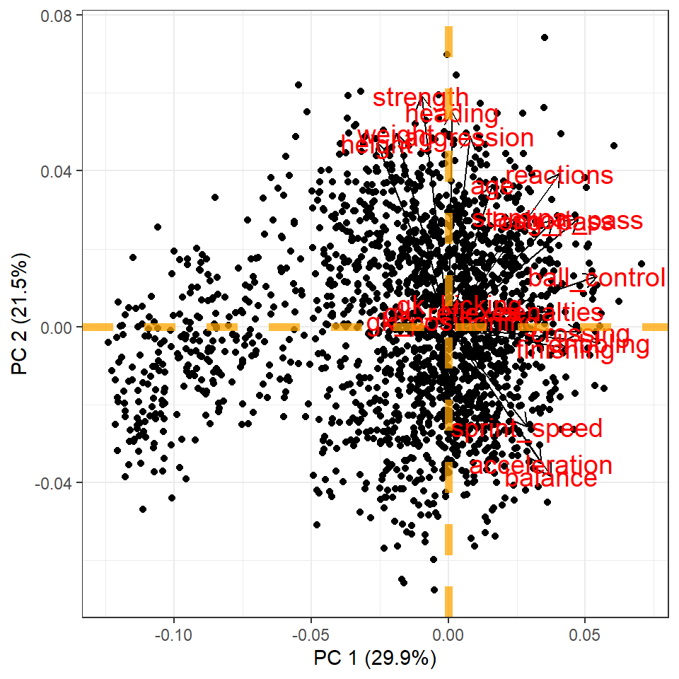

```r
txt_x = paste0("PC 1 (", 100*round(prop_varianza_mcd[1],3), "%)")
txt_y = paste0("PC 2 (", 100*round(prop_varianza_mcd[2],3), "%)")

autoplot(pca_mcd,
         data = fifa_subset,
         loadings = TRUE,
         loadings.colour = 'black',
         loadings.label = TRUE,
         loadings.label.size = 5) +
  geom_vline(xintercept = 0, linetype = "dashed", color = "orange", size=2, alpha=0.75) +
  geom_hline(yintercept = 0, linetype = "dashed", color = "orange", size=2, alpha=0.75)+
  theme_bw()  + xlab(txt_x) + ylab(txt_y)
```